# Problem Set 5

Deadline: Tuesday Nov 29th at 11:59 pm

# 1 General Social Survey

We will work on the `gss_cat` dataset. We would like to know the distribution of the income variable.

1. The following code makes a default bar chart for the `rincome` (reported income). However, it doesn’t look good. What makes the default bar chart hard to understand?

```r
gss_cat %>%
  ggplot(aes(x = rincome)) +
  geom_bar()
```

2. Let’s make this bar chart better (example shown below):
1. remove the rows with value “Not applicable”
2. rename “Lt $1000” to “Less than $1000”
3. use color to distinguish non-response categories (“Refused”, “Don’t know”, and “No answer”) from income levels (“Lt $1000”, …) (Hint: creat a boolean variable to indicate whether `rincome` belongs to non-response categories and then map the fill aesthetic in `geom_bar` to this variable.)
4. add meaningful y- and x-axis titles
5. flip the coordinate

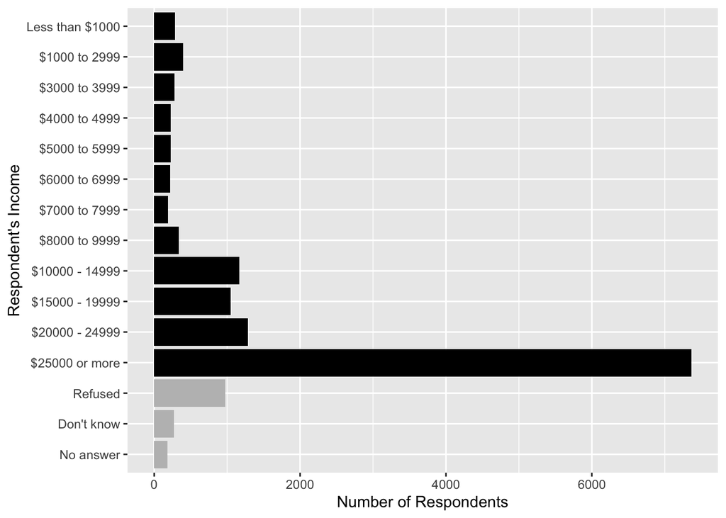

# 2 `who` data

We will work on the `who` dataset (use the help page to get more details about the data). First, let’s transform the data based on what we did in class to obtain the `who2` data.

```r
names(who) <- str_replace(names(who), "newrel", "new_rel")
who2 <- who %>%
  pivot_longer(5:60, names_to="codes", values_to="case" ) %>%
  select(-iso2, -iso3) %>%
  separate(codes, c("new", "type", "sexage"), sep = "_") %>%
  select(-new) %>%
  separate(sexage, into = c("sex", "age"), sep = 1,convert=TRUE)
```

1. There are many missing values in the case variable. We need to think about how missing values are represented in this dataset. The main concern is whether a missing value means that there were no cases of Tuberculosis (TB) or whether it means that the WHO does not have data on the number of TB cases. Check the presence of zeroes in the case variable. (If there are zeroes in the data, then the missing values means WHO doe not have data.)
2. We would like to know the time trend for the total number of cases of TB for males and females separately. Make a time series plot of the total number of cases (exmaple shown below). What do you find from the plot?

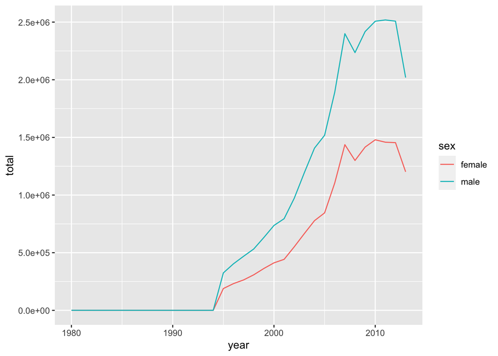

3. Let’s plot the number of cases for each age group for males and females.

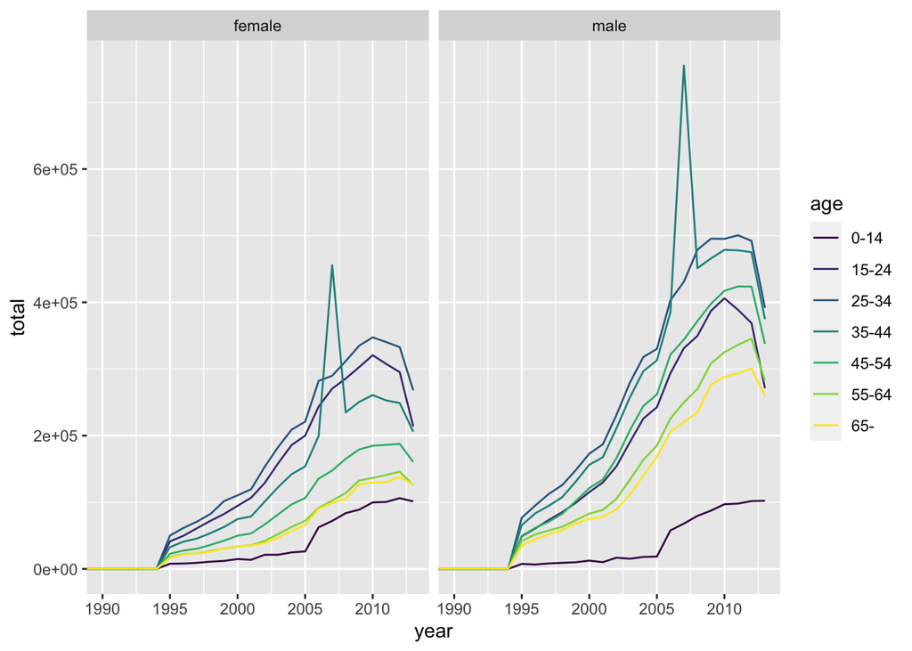

4. There are too many lines in the previous plot. Collapse the age groups into five categories 0-14,15-24, 25-44, 45-64,65-. What do you find?

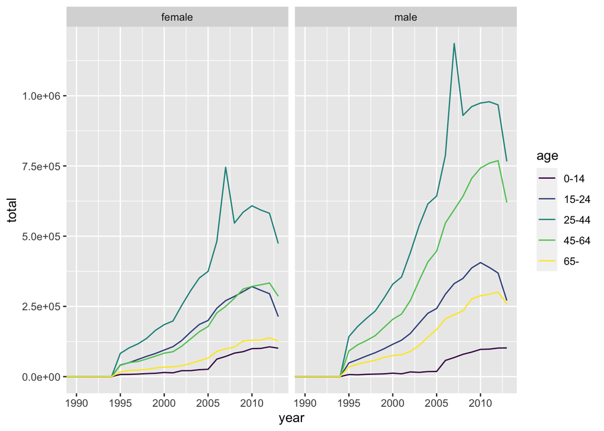

# 3 More and more on `flights` dataset

1. Explain what the following code does.

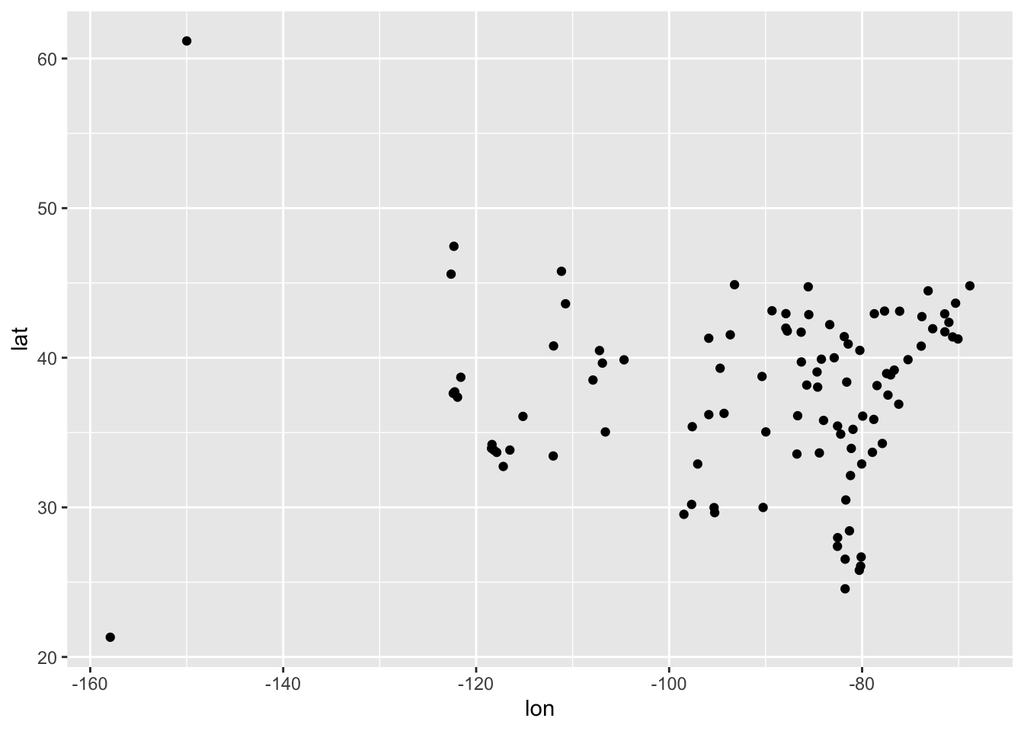

```r
airports %>%
  semi_join(flights, c("faa" = "dest")) %>%
  ggplot(aes(lon, lat))+
  geom_point()
```

2. Here’s an easy way to draw a map of the United States. The borders() function adds the borders for the states. (You need to install and load the maps package.)

```r
airports %>%
  semi_join(flights, c("faa" = "dest")) %>%
  ggplot(aes(lon, lat)) +
  borders("state") +
  geom_point() +
  coord_quickmap()
```

Modify the code to show the spatial distribution of delays. You need to

1. compute the average arrival delay by destination from the flights data
2. join on the airports data to get the longitude and latitude of each destination
3. plot each destination with the average arrival delay mapping to the size or color aesthetic (map a continuous variable to color or size will generate a bar in the legend)
4. add the borders of the states and change the coordinate using coord_quickmap()

Below is an example.

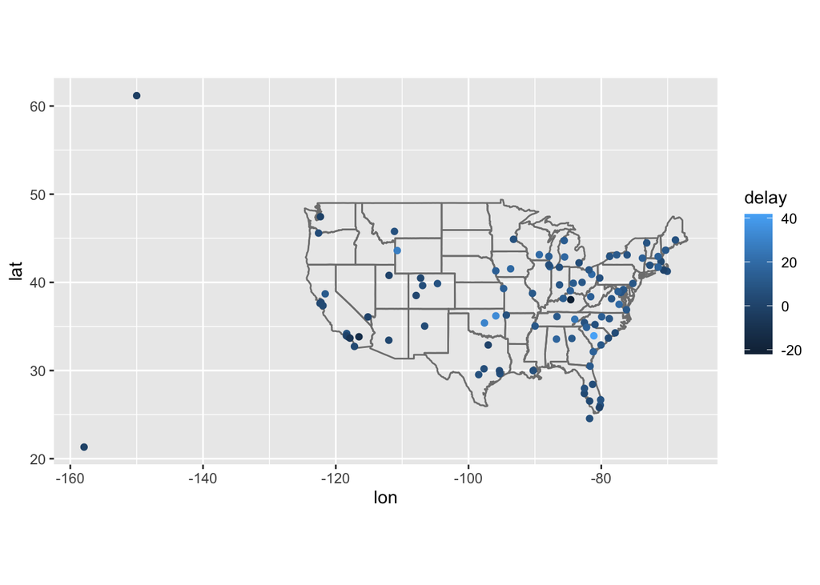

Let’s draw the route (approximately) each plane flies from its origin to its destination. Below is an example

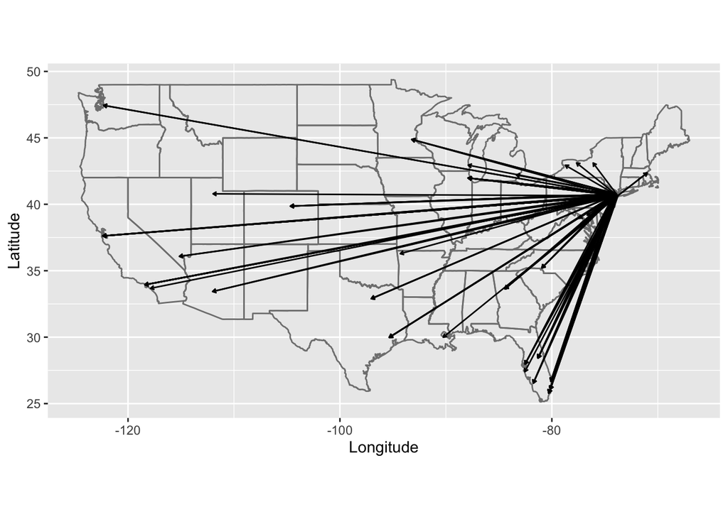

We will break this into two subquestions.

3. We need to first get the longitude and latitude of the origin and destination of each flight. You need to
1. Join flights on airports by origin to get the longitude and latitude of the orgin
2. Then join flights on airports by destination to get the longitude and latitude of the origin

(Be careful about the duplicated columns since you join on the airports data twice. R will assign suffix for duplicated names but you could also rename the columns before or after joining.)

4. We draw the route only for the first 100 flights:
1. use slice(1:100) to extract the first 100 rows from the data obtained in (c)
2. use geom_segment to draw the route for each flight. Check arrow argument to adjust the size of the arrow
3. add the borders of the states and change the coordinate using coord_quickmap()
5. Let’s explore the relationship between the age of a plane (each plane is represented by tailnum) and its delay. The year variable in the planes data shows the year manufactured (so 2013-year is the age). Following the steps to draw a figure (below is an exmaple):

1.join flights on planes (note the flights also has a variable year) 2. calculate the age of the plane 3. calculate the average departure delay and arrival delay by age 4. pivot longer the average arr_delay and dep_delay columns into a key:value column pair names type and delay 5. recode the levels of type column to be “Departure” and “Arrival” 6. create the plot

Let’s focus on the part with age <20. What do you find about the relationship between the age of a plane and its delay?

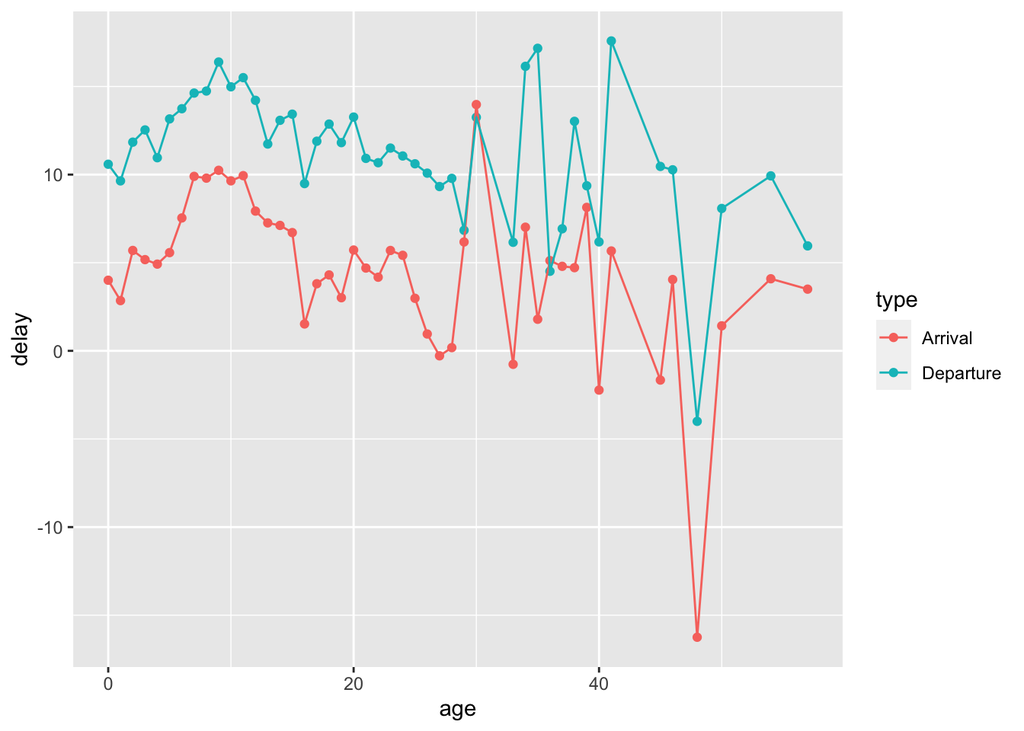